# Risk Factor Analysis

## Outcome Variable

**Outcome Variable:** y_rate_len

## Predictor Variables

**Intervention Variable:** gagebrth

**Adjustment Set:**

unadjusted

## Stratifying Variables

The analysis was stratified on these variable(s):

- agecat
- studyid
- country

## Data Summary

| agecat | studyid | country | gagebrth | n_cell | n |
| --- | --- | --- | --- | --- | --- |
| 0-3 months | CMC-V-BCS-2002 | INDIA | Full or late term | 54 | 87 |
| 0-3 months | CMC-V-BCS-2002 | INDIA | Preterm | 11 | 87 |
| 0-3 months | CMC-V-BCS-2002 | INDIA | Early term | 22 | 87 |
| 0-3 months | COHORTS | GUATEMALA | Full or late term | 304 | 551 |
| 0-3 months | COHORTS | GUATEMALA | Preterm | 87 | 551 |
| 0-3 months | COHORTS | GUATEMALA | Early term | 160 | 551 |
| 0-3 months | COHORTS | INDIA | Full or late term | 561 | 1274 |
| 0-3 months | COHORTS | INDIA | Preterm | 279 | 1274 |
| 0-3 months | COHORTS | INDIA | Early term | 434 | 1274 |
| 0-3 months | IRC | INDIA | Full or late term | 230 | 359 |
| 0-3 months | IRC | INDIA | Preterm | 36 | 359 |
| 0-3 months | IRC | INDIA | Early term | 93 | 359 |
| 0-3 months | JiVitA-3 | BANGLADESH | Full or late term | 9816 | 18973 |
| 0-3 months | JiVitA-3 | BANGLADESH | Preterm | 3851 | 18973 |
| 0-3 months | JiVitA-3 | BANGLADESH | Early term | 5306 | 18973 |
| 0-3 months | Keneba | GAMBIA | Full or late term | 598 | 1232 |
| 0-3 months | Keneba | GAMBIA | Preterm | 183 | 1232 |
| 0-3 months | Keneba | GAMBIA | Early term | 451 | 1232 |
| 0-3 months | NIH-Crypto | BANGLADESH | Full or late term | 162 | 721 |
| 0-3 months | NIH-Crypto | BANGLADESH | Preterm | 252 | 721 |
| 0-3 months | NIH-Crypto | BANGLADESH | Early term | 307 | 721 |
| 0-3 months | PROBIT | BELARUS | Full or late term | 7824 | 15323 |
| 0-3 months | PROBIT | BELARUS | Preterm | 537 | 15323 |
| 0-3 months | PROBIT | BELARUS | Early term | 6962 | 15323 |
| 3-6 months | CMC-V-BCS-2002 | INDIA | Full or late term | 174 | 288 |
| 3-6 months | CMC-V-BCS-2002 | INDIA | Preterm | 44 | 288 |
| 3-6 months | CMC-V-BCS-2002 | INDIA | Early term | 70 | 288 |
| 3-6 months | COHORTS | GUATEMALA | Full or late term | 338 | 626 |
| 3-6 months | COHORTS | GUATEMALA | Preterm | 106 | 626 |
| 3-6 months | COHORTS | GUATEMALA | Early term | 182 | 626 |

[output cut: 150 more lines]

The following strata were considered:

- agecat: 0-3 months, studyid: CMC-V-BCS-2002, country: INDIA
- agecat: 0-3 months, studyid: COHORTS, country: GUATEMALA
- agecat: 0-3 months, studyid: COHORTS, country: INDIA
- agecat: 0-3 months, studyid: IRC, country: INDIA
- agecat: 0-3 months, studyid: JiVitA-3, country: BANGLADESH
- agecat: 0-3 months, studyid: Keneba, country: GAMBIA
- agecat: 0-3 months, studyid: NIH-Crypto, country: BANGLADESH
- agecat: 0-3 months, studyid: PROBIT, country: BELARUS
- agecat: 12-15 months, studyid: CMC-V-BCS-2002, country: INDIA
- agecat: 12-15 months, studyid: COHORTS, country: GUATEMALA
- agecat: 12-15 months, studyid: IRC, country: INDIA
- agecat: 12-15 months, studyid: Keneba, country: GAMBIA
- agecat: 12-15 months, studyid: NIH-Crypto, country: BANGLADESH
- agecat: 12-15 months, studyid: PROBIT, country: BELARUS
- agecat: 12-15 months, studyid: TanzaniaChild2, country: TANZANIA, UNITED REPUBLIC OF
- agecat: 15-18 months, studyid: CMC-V-BCS-2002, country: INDIA
- agecat: 15-18 months, studyid: COHORTS, country: GUATEMALA
- agecat: 15-18 months, studyid: IRC, country: INDIA
- agecat: 15-18 months, studyid: Keneba, country: GAMBIA
- agecat: 15-18 months, studyid: NIH-Crypto, country: BANGLADESH
- agecat: 15-18 months, studyid: PROBIT, country: BELARUS
- agecat: 15-18 months, studyid: TanzaniaChild2, country: TANZANIA, UNITED REPUBLIC OF
- agecat: 18-21 months, studyid: CMC-V-BCS-2002, country: INDIA
- agecat: 18-21 months, studyid: COHORTS, country: GUATEMALA
- agecat: 18-21 months, studyid: IRC, country: INDIA
- agecat: 18-21 months, studyid: Keneba, country: GAMBIA
- agecat: 18-21 months, studyid: NIH-Crypto, country: BANGLADESH
- agecat: 18-21 months, studyid: PROBIT, country: BELARUS
- agecat: 18-21 months, studyid: TanzaniaChild2, country: TANZANIA, UNITED REPUBLIC OF
- agecat: 21-24 months, studyid: CMC-V-BCS-2002, country: INDIA
- agecat: 21-24 months, studyid: COHORTS, country: GUATEMALA
- agecat: 21-24 months, studyid: IRC, country: INDIA
- agecat: 21-24 months, studyid: Keneba, country: GAMBIA
- agecat: 21-24 months, studyid: NIH-Crypto, country: BANGLADESH
- agecat: 21-24 months, studyid: PROBIT, country: BELARUS
- agecat: 3-6 months, studyid: CMC-V-BCS-2002, country: INDIA
- agecat: 3-6 months, studyid: COHORTS, country: GUATEMALA
- agecat: 3-6 months, studyid: COHORTS, country: INDIA
- agecat: 3-6 months, studyid: IRC, country: INDIA
- agecat: 3-6 months, studyid: JiVitA-3, country: BANGLADESH
- agecat: 3-6 months, studyid: Keneba, country: GAMBIA
- agecat: 3-6 months, studyid: NIH-Crypto, country: BANGLADESH
- agecat: 3-6 months, studyid: PROBIT, country: BELARUS
- agecat: 3-6 months, studyid: TanzaniaChild2, country: TANZANIA, UNITED REPUBLIC OF
- agecat: 6-9 months, studyid: CMC-V-BCS-2002, country: INDIA
- agecat: 6-9 months, studyid: COHORTS, country: GUATEMALA
- agecat: 6-9 months, studyid: COHORTS, country: INDIA
- agecat: 6-9 months, studyid: IRC, country: INDIA
- agecat: 6-9 months, studyid: Keneba, country: GAMBIA
- agecat: 6-9 months, studyid: NIH-Crypto, country: BANGLADESH
- agecat: 6-9 months, studyid: PROBIT, country: BELARUS
- agecat: 6-9 months, studyid: TanzaniaChild2, country: TANZANIA, UNITED REPUBLIC OF
- agecat: 9-12 months, studyid: CMC-V-BCS-2002, country: INDIA
- agecat: 9-12 months, studyid: COHORTS, country: GUATEMALA
- agecat: 9-12 months, studyid: COHORTS, country: INDIA
- agecat: 9-12 months, studyid: IRC, country: INDIA
- agecat: 9-12 months, studyid: Keneba, country: GAMBIA
- agecat: 9-12 months, studyid: NIH-Crypto, country: BANGLADESH
- agecat: 9-12 months, studyid: PROBIT, country: BELARUS
- agecat: 9-12 months, studyid: TanzaniaChild2, country: TANZANIA, UNITED REPUBLIC OF

### Dropped Strata

Some strata were dropped due to rare outcomes:

- agecat: 18-21 months, studyid: TanzaniaChild2, country: TANZANIA, UNITED REPUBLIC OF

## Methods Detail

We’re interested in the causal parameters $E[Y_a]$ for all values of $a \in \mathcal{A}$. These parameters represent the mean outcome if, possibly contrary to fact, we intervened to set all units to have $A=a$. Under the randomization and positivity assumptions, these are identified by the statistical parameters $\psi_a=E_W[E_{Y|A,W}(Y|A=a,W)]$. In addition, we’re interested in the mean of $Y$, $E[Y]$ under no intervention (the observed mean). We will estimate these parameters by using SuperLearner to fit the relevant likelihood factors – $E_{Y|A,W}(Y|A=a,W)$ and $p(A=a|W)$, and then updating our likelihood fit using a joint TMLE.

For unadjusted analyses ($W=\{\}$), initial likelihoods were estimated using Lrnr_glm to estimate the simple $E(Y|A)$ and Lrnr_mean to estimate $p(A)$. For adjusted analyses, a small library containing Lrnr_glmnet, Lrnr_xgboost, and Lrnr_mean was used.

Having estimated these parameters, we will then use the delta method to estimate relative risks and attributable risks relative to a prespecified baseline level of $A$.

# Results Detail

## Results Plots

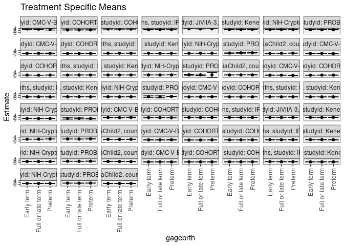

[figure not shown]

[figure not shown]

## Results Table

### Parameter: TSM

| agecat | studyid | country | intervention_level | baseline_level | estimate | ci_lower | ci_upper |
| --- | --- | --- | --- | --- | --- | --- | --- |
| 0-3 months | CMC-V-BCS-2002 | INDIA | Full or late term | NA | 3.4647191 | 3.1982214 | 3.7312168 |
| 0-3 months | CMC-V-BCS-2002 | INDIA | Preterm | NA | 3.2487648 | 2.4864506 | 4.0110789 |
| 0-3 months | CMC-V-BCS-2002 | INDIA | Early term | NA | 3.6258967 | 3.2442769 | 4.0075164 |
| 0-3 months | COHORTS | GUATEMALA | Full or late term | NA | 2.5970596 | 2.5322397 | 2.6618795 |
| 0-3 months | COHORTS | GUATEMALA | Preterm | NA | 2.6569808 | 2.5205431 | 2.7934185 |
| 0-3 months | COHORTS | GUATEMALA | Early term | NA | 2.5694851 | 2.4773884 | 2.6615819 |
| 0-3 months | COHORTS | INDIA | Full or late term | NA | 3.4932940 | 3.4448078 | 3.5417803 |
| 0-3 months | COHORTS | INDIA | Preterm | NA | 3.5435234 | 3.4755984 | 3.6114484 |
| 0-3 months | COHORTS | INDIA | Early term | NA | 3.5640695 | 3.5078680 | 3.6202711 |
| 0-3 months | IRC | INDIA | Full or late term | NA | 3.2201814 | 3.0758246 | 3.3645381 |
| 0-3 months | IRC | INDIA | Preterm | NA | 3.1018411 | 2.7726998 | 3.4309824 |
| 0-3 months | IRC | INDIA | Early term | NA | 2.9717078 | 2.7639613 | 3.1794543 |
| 0-3 months | JiVitA-3 | BANGLADESH | Full or late term | NA | 3.6862132 | 3.6732660 | 3.6991603 |
| 0-3 months | JiVitA-3 | BANGLADESH | Preterm | NA | 3.7769530 | 3.7551301 | 3.7987759 |
| 0-3 months | JiVitA-3 | BANGLADESH | Early term | NA | 3.7653468 | 3.7473992 | 3.7832944 |
| 0-3 months | Keneba | GAMBIA | Full or late term | NA | 3.0840208 | 3.0150916 | 3.1529501 |
| 0-3 months | Keneba | GAMBIA | Preterm | NA | 3.2243371 | 3.0833929 | 3.3652814 |
| 0-3 months | Keneba | GAMBIA | Early term | NA | 3.0959016 | 3.0273087 | 3.1644944 |
| 0-3 months | NIH-Crypto | BANGLADESH | Full or late term | NA | 3.2069104 | 3.1250887 | 3.2887320 |
| 0-3 months | NIH-Crypto | BANGLADESH | Preterm | NA | 3.1334462 | 3.0756713 | 3.1912210 |
| 0-3 months | NIH-Crypto | BANGLADESH | Early term | NA | 3.0848131 | 3.0288874 | 3.1407388 |
| 0-3 months | PROBIT | BELARUS | Full or late term | NA | 2.7868004 | 2.6753984 | 2.8982023 |
| 0-3 months | PROBIT | BELARUS | Preterm | NA | 2.9236668 | 2.7493704 | 3.0979633 |
| 0-3 months | PROBIT | BELARUS | Early term | NA | 2.8347893 | 2.7132919 | 2.9562867 |
| 3-6 months | CMC-V-BCS-2002 | INDIA | Full or late term | NA | 1.7243159 | 1.5815654 | 1.8670664 |
| 3-6 months | CMC-V-BCS-2002 | INDIA | Preterm | NA | 2.0037911 | 1.7270187 | 2.2805635 |
| 3-6 months | CMC-V-BCS-2002 | INDIA | Early term | NA | 1.8953710 | 1.7198881 | 2.0708540 |
| 3-6 months | COHORTS | GUATEMALA | Full or late term | NA | 1.7534936 | 1.7068958 | 1.8000913 |
| 3-6 months | COHORTS | GUATEMALA | Preterm | NA | 1.7150647 | 1.6169303 | 1.8131990 |
| 3-6 months | COHORTS | GUATEMALA | Early term | NA | 1.7815984 | 1.7219740 | 1.8412229 |

[output cut: 147 more lines]

### Parameter: E(Y)

| agecat | studyid | country | intervention_level | baseline_level | estimate | ci_lower | ci_upper |
| --- | --- | --- | --- | --- | --- | --- | --- |
| 0-3 months | CMC-V-BCS-2002 | INDIA | NA | NA | 3.4781721 | 3.2625045 | 3.6938397 |
| 0-3 months | COHORTS | GUATEMALA | NA | NA | 2.5985138 | 2.5488776 | 2.6481499 |
| 0-3 months | COHORTS | INDIA | NA | NA | 3.5284044 | 3.4960504 | 3.5607583 |
| 0-3 months | IRC | INDIA | NA | NA | 3.1439466 | 3.0314146 | 3.2564786 |
| 0-3 months | JiVitA-3 | BANGLADESH | NA | NA | 3.7267614 | 3.7161625 | 3.7373603 |
| 0-3 months | Keneba | GAMBIA | NA | NA | 3.1092125 | 3.0623560 | 3.1560689 |
| 0-3 months | NIH-Crypto | BANGLADESH | NA | NA | 3.1292449 | 3.0928504 | 3.1656393 |
| 0-3 months | PROBIT | BELARUS | NA | NA | 2.8134007 | 2.6999348 | 2.9268665 |
| 3-6 months | CMC-V-BCS-2002 | INDIA | NA | NA | 1.8085894 | 1.7027345 | 1.9144443 |
| 3-6 months | COHORTS | GUATEMALA | NA | NA | 1.7551575 | 1.7203355 | 1.7899795 |
| 3-6 months | COHORTS | INDIA | NA | NA | 1.8699710 | 1.8423785 | 1.8975635 |
| 3-6 months | IRC | INDIA | NA | NA | 1.8770590 | 1.8115784 | 1.9425395 |
| 3-6 months | JiVitA-3 | BANGLADESH | NA | NA | 1.9213079 | 1.9107007 | 1.9319152 |
| 3-6 months | Keneba | GAMBIA | NA | NA | 1.9509973 | 1.9060862 | 1.9959083 |
| 3-6 months | NIH-Crypto | BANGLADESH | NA | NA | 2.0057973 | 1.9693775 | 2.0422170 |
| 3-6 months | PROBIT | BELARUS | NA | NA | 2.0915582 | 2.0504573 | 2.1326590 |
| 3-6 months | TanzaniaChild2 | TANZANIA, UNITED REPUBLIC OF | NA | NA | 1.7929660 | 1.7563132 | 1.8296188 |
| 6-9 months | CMC-V-BCS-2002 | INDIA | NA | NA | 1.2220973 | 1.1425692 | 1.3016254 |
| 6-9 months | COHORTS | GUATEMALA | NA | NA | 1.1096071 | 1.0783734 | 1.1408408 |
| 6-9 months | COHORTS | INDIA | NA | NA | 1.2025422 | 1.1774451 | 1.2276393 |
| 6-9 months | IRC | INDIA | NA | NA | 1.3734741 | 1.3233361 | 1.4236120 |
| 6-9 months | Keneba | GAMBIA | NA | NA | 1.4194056 | 1.3572790 | 1.4815322 |
| 6-9 months | NIH-Crypto | BANGLADESH | NA | NA | 1.3282695 | 1.2988292 | 1.3577098 |
| 6-9 months | PROBIT | BELARUS | NA | NA | 1.5766123 | 1.5455111 | 1.6077135 |
| 6-9 months | TanzaniaChild2 | TANZANIA, UNITED REPUBLIC OF | NA | NA | 1.3321083 | 1.2954511 | 1.3687654 |
| 9-12 months | CMC-V-BCS-2002 | INDIA | NA | NA | 0.9032608 | 0.8332861 | 0.9732355 |
| 9-12 months | COHORTS | GUATEMALA | NA | NA | 0.9406753 | 0.9124512 | 0.9688994 |
| 9-12 months | COHORTS | INDIA | NA | NA | 0.9959823 | 0.9703083 | 1.0216563 |
| 9-12 months | IRC | INDIA | NA | NA | 1.1211074 | 1.0804846 | 1.1617303 |
| 9-12 months | Keneba | GAMBIA | NA | NA | 0.9656523 | 0.9150056 | 1.0162991 |
| 9-12 months | NIH-Crypto | BANGLADESH | NA | NA | 1.1234745 | 1.0972274 | 1.1497215 |
| 9-12 months | PROBIT | BELARUS | NA | NA | 1.3719414 | 1.3218894 | 1.4219934 |
| 9-12 months | TanzaniaChild2 | TANZANIA, UNITED REPUBLIC OF | NA | NA | 1.0782604 | 1.0432786 | 1.1132422 |
| 12-15 months | CMC-V-BCS-2002 | INDIA | NA | NA | 0.8467707 | 0.7759867 | 0.9175546 |
| 12-15 months | COHORTS | GUATEMALA | NA | NA | 0.7678925 | 0.7344642 | 0.8013208 |
| 12-15 months | IRC | INDIA | NA | NA | 0.9599041 | 0.9167165 | 1.0030917 |
| 12-15 months | Keneba | GAMBIA | NA | NA | 0.9371227 | 0.9040056 | 0.9702398 |
| 12-15 months | NIH-Crypto | BANGLADESH | NA | NA | 0.9711395 | 0.9465805 | 0.9956985 |
| 12-15 months | PROBIT | BELARUS | NA | NA | 1.1869393 | 0.8605053 | 1.5133732 |
| 12-15 months | TanzaniaChild2 | TANZANIA, UNITED REPUBLIC OF | NA | NA | 0.9264450 | 0.8889856 | 0.9639045 |
| 15-18 months | CMC-V-BCS-2002 | INDIA | NA | NA | 0.7339914 | 0.6677283 | 0.8002545 |
| 15-18 months | COHORTS | GUATEMALA | NA | NA | 0.7409680 | 0.7058314 | 0.7761045 |
| 15-18 months | IRC | INDIA | NA | NA | 0.8600773 | 0.8188836 | 0.9012711 |
| 15-18 months | Keneba | GAMBIA | NA | NA | 0.8859463 | 0.8495013 | 0.9223913 |
| 15-18 months | NIH-Crypto | BANGLADESH | NA | NA | 0.9177168 | 0.8947657 | 0.9406678 |
| 15-18 months | PROBIT | BELARUS | NA | NA | 1.0339982 | 0.5968654 | 1.4711310 |
| 15-18 months | TanzaniaChild2 | TANZANIA, UNITED REPUBLIC OF | NA | NA | 0.9495144 | 0.9074149 | 0.9916139 |
| 18-21 months | CMC-V-BCS-2002 | INDIA | NA | NA | 0.6999385 | 0.6329765 | 0.7669004 |
| 18-21 months | COHORTS | GUATEMALA | NA | NA | 0.7539443 | 0.7205389 | 0.7873497 |
| 18-21 months | IRC | INDIA | NA | NA | 0.7524690 | 0.7136632 | 0.7912748 |
| 18-21 months | Keneba | GAMBIA | NA | NA | 0.8368158 | 0.7971504 | 0.8764812 |
| 18-21 months | NIH-Crypto | BANGLADESH | NA | NA | 0.7977755 | 0.7744353 | 0.8211158 |
| 18-21 months | PROBIT | BELARUS | NA | NA | 0.8948530 | 0.2840229 | 1.5056831 |
| 21-24 months | CMC-V-BCS-2002 | INDIA | NA | NA | 0.7100839 | 0.6450853 | 0.7750826 |
| 21-24 months | COHORTS | GUATEMALA | NA | NA | 0.6668096 | 0.6383726 | 0.6952467 |
| 21-24 months | IRC | INDIA | NA | NA | 0.7110023 | 0.6683984 | 0.7536061 |
| 21-24 months | Keneba | GAMBIA | NA | NA | 0.7083004 | 0.6696346 | 0.7469662 |
| 21-24 months | NIH-Crypto | BANGLADESH | NA | NA | 0.7993353 | 0.7748026 | 0.8238681 |
| 21-24 months | PROBIT | BELARUS | NA | NA | 0.9164106 | 0.4532958 | 1.3795255 |

### Parameter: ATE

| agecat | studyid | country | intervention_level | baseline_level | estimate | ci_lower | ci_upper |
| --- | --- | --- | --- | --- | --- | --- | --- |
| 0-3 months | CMC-V-BCS-2002 | INDIA | Full or late term | Full or late term | 0.0000000 | 0.0000000 | 0.0000000 |
| 0-3 months | CMC-V-BCS-2002 | INDIA | Preterm | Full or late term | -0.2159543 | -1.0235086 | 0.5915999 |
| 0-3 months | CMC-V-BCS-2002 | INDIA | Early term | Full or late term | 0.1611776 | -0.3042842 | 0.6266393 |
| 0-3 months | COHORTS | GUATEMALA | Full or late term | Full or late term | 0.0000000 | 0.0000000 | 0.0000000 |
| 0-3 months | COHORTS | GUATEMALA | Preterm | Full or late term | 0.0599212 | -0.0911313 | 0.2109737 |
| 0-3 months | COHORTS | GUATEMALA | Early term | Full or late term | -0.0275745 | -0.1401953 | 0.0850463 |
| 0-3 months | COHORTS | INDIA | Full or late term | Full or late term | 0.0000000 | 0.0000000 | 0.0000000 |
| 0-3 months | COHORTS | INDIA | Preterm | Full or late term | 0.0502294 | -0.0332256 | 0.1336843 |
| 0-3 months | COHORTS | INDIA | Early term | Full or late term | 0.0707755 | -0.0034507 | 0.1450018 |
| 0-3 months | IRC | INDIA | Full or late term | Full or late term | 0.0000000 | 0.0000000 | 0.0000000 |
| 0-3 months | IRC | INDIA | Preterm | Full or late term | -0.1183403 | -0.4777466 | 0.2410660 |
| 0-3 months | IRC | INDIA | Early term | Full or late term | -0.2484736 | -0.5014508 | 0.0045037 |
| 0-3 months | JiVitA-3 | BANGLADESH | Full or late term | Full or late term | 0.0000000 | 0.0000000 | 0.0000000 |
| 0-3 months | JiVitA-3 | BANGLADESH | Preterm | Full or late term | 0.0907399 | 0.0664034 | 0.1150764 |
| 0-3 months | JiVitA-3 | BANGLADESH | Early term | Full or late term | 0.0791336 | 0.0588643 | 0.0994029 |
| 0-3 months | Keneba | GAMBIA | Full or late term | Full or late term | 0.0000000 | 0.0000000 | 0.0000000 |
| 0-3 months | Keneba | GAMBIA | Preterm | Full or late term | 0.1403163 | -0.0165802 | 0.2972128 |
| 0-3 months | Keneba | GAMBIA | Early term | Full or late term | 0.0118807 | -0.0853624 | 0.1091238 |
| 0-3 months | NIH-Crypto | BANGLADESH | Full or late term | Full or late term | 0.0000000 | 0.0000000 | 0.0000000 |
| 0-3 months | NIH-Crypto | BANGLADESH | Preterm | Full or late term | -0.0734642 | -0.1736276 | 0.0266993 |
| 0-3 months | NIH-Crypto | BANGLADESH | Early term | Full or late term | -0.1220972 | -0.2212056 | -0.0229889 |
| 0-3 months | PROBIT | BELARUS | Full or late term | Full or late term | 0.0000000 | 0.0000000 | 0.0000000 |
| 0-3 months | PROBIT | BELARUS | Preterm | Full or late term | 0.1368665 | 0.0086315 | 0.2651014 |
| 0-3 months | PROBIT | BELARUS | Early term | Full or late term | 0.0479889 | -0.0118784 | 0.1078562 |
| 3-6 months | CMC-V-BCS-2002 | INDIA | Full or late term | Full or late term | 0.0000000 | 0.0000000 | 0.0000000 |
| 3-6 months | CMC-V-BCS-2002 | INDIA | Preterm | Full or late term | 0.2794752 | -0.0319420 | 0.5908924 |
| 3-6 months | CMC-V-BCS-2002 | INDIA | Early term | Full or late term | 0.1710552 | -0.0551571 | 0.3972674 |
| 3-6 months | COHORTS | GUATEMALA | Full or late term | Full or late term | 0.0000000 | 0.0000000 | 0.0000000 |
| 3-6 months | COHORTS | GUATEMALA | Preterm | Full or late term | -0.0384289 | -0.1470646 | 0.0702068 |
| 3-6 months | COHORTS | GUATEMALA | Early term | Full or late term | 0.0281048 | -0.0475683 | 0.1037780 |

[output cut: 147 more lines]

### Parameter: PAR

| agecat | studyid | country | intervention_level | baseline_level | estimate | ci_lower | ci_upper |
| --- | --- | --- | --- | --- | --- | --- | --- |
| 0-3 months | CMC-V-BCS-2002 | INDIA | Full or late term | NA | 0.0134530 | -0.1579224 | 0.1848283 |
| 0-3 months | COHORTS | GUATEMALA | Full or late term | NA | 0.0014541 | -0.0435914 | 0.0464996 |
| 0-3 months | COHORTS | INDIA | Full or late term | NA | 0.0351103 | -0.0013213 | 0.0715419 |
| 0-3 months | IRC | INDIA | Full or late term | NA | -0.0762348 | -0.1587012 | 0.0062316 |
| 0-3 months | JiVitA-3 | BANGLADESH | Full or late term | NA | 0.0405483 | 0.0319879 | 0.0491086 |
| 0-3 months | Keneba | GAMBIA | Full or late term | NA | 0.0251916 | -0.0231236 | 0.0735068 |
| 0-3 months | NIH-Crypto | BANGLADESH | Full or late term | NA | -0.0776655 | -0.1484530 | -0.0068780 |
| 0-3 months | PROBIT | BELARUS | Full or late term | NA | 0.0266003 | -0.0032523 | 0.0564529 |
| 3-6 months | CMC-V-BCS-2002 | INDIA | Full or late term | NA | 0.0842735 | 0.0008474 | 0.1676996 |
| 3-6 months | COHORTS | GUATEMALA | Full or late term | NA | 0.0016639 | -0.0305718 | 0.0338996 |
| 3-6 months | COHORTS | INDIA | Full or late term | NA | 0.0462103 | 0.0148398 | 0.0775808 |
| 3-6 months | IRC | INDIA | Full or late term | NA | 0.0235752 | -0.0267299 | 0.0738803 |
| 3-6 months | JiVitA-3 | BANGLADESH | Full or late term | NA | 0.0454060 | 0.0359301 | 0.0548819 |
| 3-6 months | Keneba | GAMBIA | Full or late term | NA | 0.0414770 | -0.0065365 | 0.0894905 |
| 3-6 months | NIH-Crypto | BANGLADESH | Full or late term | NA | 0.0570577 | -0.0133434 | 0.1274589 |
| 3-6 months | PROBIT | BELARUS | Full or late term | NA | 0.0292159 | 0.0133685 | 0.0450633 |
| 3-6 months | TanzaniaChild2 | TANZANIA, UNITED REPUBLIC OF | Full or late term | NA | 0.0236394 | -0.0057365 | 0.0530153 |
| 6-9 months | CMC-V-BCS-2002 | INDIA | Full or late term | NA | 0.0274025 | -0.0383286 | 0.0931337 |
| 6-9 months | COHORTS | GUATEMALA | Full or late term | NA | 0.0261084 | -0.0021109 | 0.0543276 |
| 6-9 months | COHORTS | INDIA | Full or late term | NA | 0.0273290 | -0.0014494 | 0.0561075 |
| 6-9 months | IRC | INDIA | Full or late term | NA | 0.0052567 | -0.0331901 | 0.0437035 |
| 6-9 months | Keneba | GAMBIA | Full or late term | NA | -0.0158210 | -0.0855751 | 0.0539331 |
| 6-9 months | NIH-Crypto | BANGLADESH | Full or late term | NA | 0.0100496 | -0.0482899 | 0.0683890 |
| 6-9 months | PROBIT | BELARUS | Full or late term | NA | 0.0172670 | 0.0036279 | 0.0309061 |
| 6-9 months | TanzaniaChild2 | TANZANIA, UNITED REPUBLIC OF | Full or late term | NA | -0.0037177 | -0.0329119 | 0.0254765 |
| 9-12 months | CMC-V-BCS-2002 | INDIA | Full or late term | NA | -0.0202581 | -0.0736001 | 0.0330840 |
| 9-12 months | COHORTS | GUATEMALA | Full or late term | NA | -0.0049502 | -0.0301984 | 0.0202980 |
| 9-12 months | COHORTS | INDIA | Full or late term | NA | -0.0100864 | -0.0399170 | 0.0197441 |
| 9-12 months | IRC | INDIA | Full or late term | NA | 0.0119170 | -0.0179613 | 0.0417954 |
| 9-12 months | Keneba | GAMBIA | Full or late term | NA | -0.0059967 | -0.0613282 | 0.0493348 |
| 9-12 months | NIH-Crypto | BANGLADESH | Full or late term | NA | 0.0316884 | -0.0168464 | 0.0802233 |
| 9-12 months | PROBIT | BELARUS | Full or late term | NA | 0.0110653 | -0.0071757 | 0.0293063 |
| 9-12 months | TanzaniaChild2 | TANZANIA, UNITED REPUBLIC OF | Full or late term | NA | -0.0027031 | -0.0295855 | 0.0241794 |
| 12-15 months | CMC-V-BCS-2002 | INDIA | Full or late term | NA | -0.0163785 | -0.0704632 | 0.0377063 |
| 12-15 months | COHORTS | GUATEMALA | Full or late term | NA | -0.0056135 | -0.0344982 | 0.0232712 |
| 12-15 months | IRC | INDIA | Full or late term | NA | -0.0021870 | -0.0331093 | 0.0287352 |
| 12-15 months | Keneba | GAMBIA | Full or late term | NA | -0.0085514 | -0.0434788 | 0.0263761 |
| 12-15 months | NIH-Crypto | BANGLADESH | Full or late term | NA | -0.0121307 | -0.0633401 | 0.0390787 |
| 12-15 months | PROBIT | BELARUS | Full or late term | NA | -0.1086061 | -0.2522383 | 0.0350261 |
| 12-15 months | TanzaniaChild2 | TANZANIA, UNITED REPUBLIC OF | Full or late term | NA | -0.0020423 | -0.0316552 | 0.0275707 |
| 15-18 months | CMC-V-BCS-2002 | INDIA | Full or late term | NA | -0.0543066 | -0.1045381 | -0.0040751 |
| 15-18 months | COHORTS | GUATEMALA | Full or late term | NA | 0.0349565 | 0.0042220 | 0.0656910 |
| 15-18 months | IRC | INDIA | Full or late term | NA | -0.0117143 | -0.0391440 | 0.0157155 |
| 15-18 months | Keneba | GAMBIA | Full or late term | NA | -0.0006719 | -0.0367200 | 0.0353762 |
| 15-18 months | NIH-Crypto | BANGLADESH | Full or late term | NA | 0.0167921 | -0.0304529 | 0.0640372 |
| 15-18 months | PROBIT | BELARUS | Full or late term | NA | 0.0136865 | -0.4619198 | 0.4892927 |
| 15-18 months | TanzaniaChild2 | TANZANIA, UNITED REPUBLIC OF | Full or late term | NA | -0.0064920 | -0.0394664 | 0.0264824 |
| 18-21 months | CMC-V-BCS-2002 | INDIA | Full or late term | NA | -0.0305403 | -0.0862094 | 0.0251287 |
| 18-21 months | COHORTS | GUATEMALA | Full or late term | NA | -0.0104932 | -0.0396397 | 0.0186533 |
| 18-21 months | IRC | INDIA | Full or late term | NA | -0.0040534 | -0.0313037 | 0.0231969 |
| 18-21 months | Keneba | GAMBIA | Full or late term | NA | -0.0140385 | -0.0539869 | 0.0259099 |
| 18-21 months | NIH-Crypto | BANGLADESH | Full or late term | NA | 0.0135735 | -0.0363308 | 0.0634778 |
| 18-21 months | PROBIT | BELARUS | Full or late term | NA | 0.1010483 | -0.6398360 | 0.8419326 |
| 21-24 months | CMC-V-BCS-2002 | INDIA | Full or late term | NA | 0.0123635 | -0.0394793 | 0.0642063 |
| 21-24 months | COHORTS | GUATEMALA | Full or late term | NA | 0.0258289 | 0.0010327 | 0.0506251 |
| 21-24 months | IRC | INDIA | Full or late term | NA | 0.0120528 | -0.0191627 | 0.0432684 |
| 21-24 months | Keneba | GAMBIA | Full or late term | NA | 0.0333102 | -0.0064334 | 0.0730539 |
| 21-24 months | NIH-Crypto | BANGLADESH | Full or late term | NA | 0.0102328 | -0.0522574 | 0.0727230 |
| 21-24 months | PROBIT | BELARUS | Full or late term | NA | 0.0005906 | -0.4621320 | 0.4633132 |